# Homework 4

John Brandt

10/13/2017

```r
knitr::opts_chunk$set(echo = TRUE)
require(ggplot2)
```

# Import and attach dataset

```r
pollution <- read.table("Pollution_reformatted_2014.dat.txt", skip=31, sep="", header=F)
colnames(pollution) <- c("city", "state", "prec", "jant", "jult",
                         "ovr65", "popn", "educ", "hous",
                         "dens", "nonw", "wwdrk", "poor",
                         "hc", "nox", "so2", "humid", "mort")
attach(pollution)
```

# Begin model building process by looking for correlations between predictors and mortality

```r
(round(cor(pollution[,3:17], pollution[,18]),2))
```

```
##        [,1]
## prec   0.51
## jant  -0.03
## jult   0.28
## ovr65 -0.17
## popn   0.36
## educ  -0.51
## hous  -0.43
## dens   0.27
## nonw   0.64
## wwdrk -0.28
## poor   0.41
## hc    -0.18
## nox   -0.08
## so2    0.43
## humid -0.09
```

The following variables have some (>0.1) relationship with mortality * Precipitation (prec) * July temperature (jult) * Over 65 (ovr65) * Population (popn) * Education (educ) * Housing (hous) * dens (dens) * Nonwhite (nonw) * wwdrk * Poor * HC * SO2

# Build model with all predictors and model with correlated predictors

```r
lm1 <- lm(mort ~ prec + jant + jult + ovr65 + popn + educ + hous + dens +
             nonw + wwdrk + poor + hc + nox + so2 + humid)
lm2 <- lm(mort ~ prec + jult + ovr65 + popn + educ + hous + dens + nonw + wwdrk + poor + hc + so2)
```

```r
AIC(lm1, lm2)
```

```
##     df      AIC
## lm1 17 612.0597
## lm2 14 612.4748
```

```r
anova(lm1, lm2)
```

```
## Analysis of Variance Table
##
## Model 1: mort ~ prec + jant + jult + ovr65 + popn + educ + hous + dens +
##     nonw + wwdrk + poor + hc + nox + so2 + humid
## Model 2: mort ~ prec + jult + ovr65 + popn + educ + hous + dens + nonw +
##     wwdrk + poor + hc + so2
##   Res.Df   RSS Df Sum of Sq     F Pr(>F)
## 1     44 53680
## 2     47 59737 -3   -6057.5 1.655 0.1905
```

It looks as if these two models preform about as well as each other. Because of this, there is no reason to remove non-correlated variables from the model just yet.

# Determine whether to transform dependent variable

Create a residual plot as a way to test for heteroscedasticity.

It looks like the data is evenly distributed above and below the mean, as seen by a lack of slope in the linear fit.

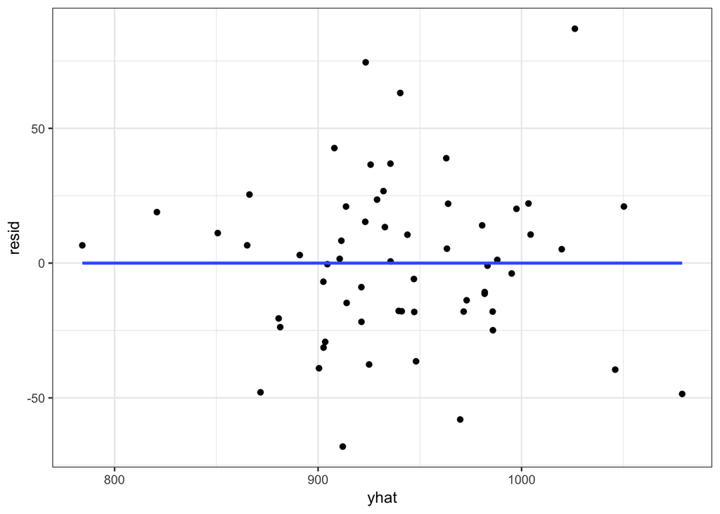

```r
resid <- residuals(lm1)
yhat <- fitted(lm1)

residplot <- ggplot(data=pollution, aes(x=yhat, y=resid))+
  geom_point()+
  geom_smooth(method="lm", se = FALSE)+
  theme_bw()

print(residplot)
```

Let’s proceed by considering multicolinearity.

# Variable Inflation Factor

```r
(model_vifs <- car::vif(lm1))
```

```
##       prec       jant       jult      ovr65       popn       educ
##   4.113888   6.143551   3.967774   7.470045   4.307618   4.860538
##       hous       dens       nonw      wwdrk       poor         hc
##   3.994781   1.658281   6.779599   2.841582   8.717068  98.639935
##        nox        so2      humid
## 104.982405   4.228929   1.907092
```

The VIF highlight that HC, NOX, poor, ovr65, and nonw need to be dealt with.

Let’s consider them individually

```r
df2 <- pollution[,c(6,11,13,14,15,18)]
round(cor(df2),2)
```

```
##       ovr65  nonw  poor    hc   nox  mort
## ovr65  1.00 -0.64 -0.31 -0.02  0.00 -0.17
## nonw  -0.64  1.00  0.70 -0.03  0.02  0.64
## poor  -0.31  0.70  1.00 -0.13 -0.10  0.41
## hc    -0.02 -0.03 -0.13  1.00  0.98 -0.18
## nox    0.00  0.02 -0.10  0.98  1.00 -0.08
## mort  -0.17  0.64  0.41 -0.18 -0.08  1.00
```

It looks like the two correlation problems we have are as follows:

HC/NOX nonw/poor/ovr65

What do we remove?

nox is poorly correlated with mort (-0.08) ovr65 is poorly correlated with mort (-.17)

So let’s try removing those 2 and leaving the other ones in the model.

# Results after the first VIF test

### Model

```r
lm3 <- lm(mort ~ prec + jant + jult + popn + educ + hous + dens +
             nonw + wwdrk + poor + hc + so2 + humid)
```

### AIC

```r
AIC(lm1, lm2, lm3)
```

```
##     df      AIC
## lm1 17 612.0597
## lm2 14 612.4748
## lm3 15 611.1951
```

### VIF

```r
(model_3_vifs <- car::vif(lm3))
```

```
##     prec     jant     jult     popn     educ     hous     dens     nonw
## 2.416070 4.381438 3.547948 2.570069 4.149246 3.882538 1.656974 4.375223
##    wwdrk     poor       hc      so2    humid
## 2.624957 7.514708 3.203499 1.772601 1.875782
```

Now, poor is the only factor in the model that is very highly colinear.

#### Correlations between poor and other predictors

```r
(round(cor(pollution[,3:17], pollution[,13]),2))
```

```
##        [,1]
## prec   0.51
## jant   0.57
## jult   0.62
## ovr65 -0.31
## popn   0.26
## educ  -0.40
## hous  -0.68
## dens  -0.16
## nonw   0.70
## wwdrk -0.19
## poor   1.00
## hc    -0.13
## nox   -0.10
## so2   -0.10
## humid -0.15
```

#### Correlation matrix

Interestingly, poor is highly correlated with: prec, jant, jult, hous, nonw

Let’s, again, consider the colinear variables.

```r
df3 <- pollution[,c(3,4,5,9,11,13,18)]
round(cor(df3),2)
```

```
##       prec  jant  jult  hous  nonw  poor  mort
## prec  1.00  0.09  0.50 -0.49  0.41  0.51  0.51
## jant  0.09  1.00  0.35  0.01  0.45  0.57 -0.03
## jult  0.50  0.35  1.00 -0.42  0.58  0.62  0.28
## hous -0.49  0.01 -0.42  1.00 -0.41 -0.68 -0.43
## nonw  0.41  0.45  0.58 -0.41  1.00  0.70  0.64
## poor  0.51  0.57  0.62 -0.68  0.70  1.00  0.41
## mort  0.51 -0.03  0.28 -0.43  0.64  0.41  1.00
```

January temperature is the first to go. It isn’t highly correlated with mort (-0.03) and is highly colinear with poor (0.57).

Let’s remove it from the model.

Precipitation is also highly colinear with poor. There is no reason we would qualitatively expect precipitation to increase mortality, so we’re going to remove it from the model as well.

# Model with colinear variables removed

```r
lm4 <- lm(mort ~ jult + popn + educ + hous + dens +
             nonw + wwdrk + poor + hc + so2 + humid)
```

```r
(model_vifs <- car::vif(lm4))
```

```
##     jult     popn     educ     hous     dens     nonw    wwdrk     poor
## 3.191079 2.340220 3.841653 2.822906 1.649918 3.975969 2.495179 4.769152
##       hc      so2    humid
## 2.051622 1.656161 1.619717
```

These look better, but we haven’t even considered the result of our models yet!

Let’s do that.

```r
summary(lm4)
```

```
##
## Call:
## lm(formula = mort ~ jult + popn + educ + hous + dens + nonw +
##     wwdrk + poor + hc + so2 + humid)
##
## Residuals:
##     Min      1Q  Median      3Q     Max
## -72.595 -21.141  -3.033  17.499  96.366
##
## Coefficients:
##               Estimate Std. Error t value Pr(>|t|)
## (Intercept)  1.873e+03  3.345e+02   5.599 1.02e-06 ***
## jult        -3.209e+00  1.790e+00  -1.793   0.0793 .
## popn        -8.217e+01  5.397e+01  -1.522   0.1345
## educ        -1.432e+01  1.107e+01  -1.294   0.2019
## hous        -2.353e+00  1.559e+00  -1.509   0.1379
## dens         3.776e-03  4.215e-03   0.896   0.3748
## nonw         5.912e+00  1.067e+00   5.543 1.24e-06 ***
## wwdrk       -1.681e+00  1.634e+00  -1.029   0.3088
## poor        -3.420e+00  2.505e+00  -1.365   0.1785
## hc          -1.799e-01  7.431e-02  -2.421   0.0193 *
## so2          2.384e-01  9.688e-02   2.461   0.0175 *
## humid       -7.253e-01  1.131e+00  -0.641   0.5244
## ---
## Signif. codes:  0 '***' 0.001 '**' 0.01 '*' 0.05 '.' 0.1 ' ' 1
##
## Residual standard error: 36.65 on 48 degrees of freedom
## Multiple R-squared:  0.7175, Adjusted R-squared:  0.6528
## F-statistic: 11.08 on 11 and 48 DF,  p-value: 8.093e-10
```

# Simplifying model by removing non-significant predictors

Dens, wwdrk, and humid are all highly nonsignificant (p>0.3)

```r
lm5 <- lm(mort ~ jult + popn + educ + hous +
             nonw + poor + hc + so2)
```

```r
anova(lm5, lm4)
```

```
## Analysis of Variance Table
##
## Model 1: mort ~ jult + popn + educ + hous + nonw + poor + hc + so2
## Model 2: mort ~ jult + popn + educ + hous + dens + nonw + wwdrk + poor +
##     hc + so2 + humid
##   Res.Df   RSS Df Sum of Sq      F Pr(>F)
## 1     51 67426
## 2     48 64492  3    2934.1 0.7279 0.5404
```

Adding the nonsignificant variables back into the model indeed does not improve the model fit, because the partial F-tests were not significant, so let’s keep them out.

```r
summary(lm5)
```

```
##
## Call:
## lm(formula = mort ~ jult + popn + educ + hous + nonw + poor +
##     hc + so2)
##
## Residuals:
##     Min      1Q  Median      3Q     Max
## -85.400 -21.756  -2.156  19.619  85.381
##
## Coefficients:
##               Estimate Std. Error t value Pr(>|t|)
## (Intercept) 1791.80135  266.95459   6.712 1.55e-08 ***
## jult          -2.64974    1.44757  -1.830  0.07303 .
## popn         -73.10753   46.86854  -1.560  0.12498
## educ         -24.49838    7.95803  -3.078  0.00335 **
## hous          -2.05880    1.51599  -1.358  0.18042
## nonw           5.73734    0.97414   5.890 3.05e-07 ***
## poor          -3.86232    2.40397  -1.607  0.11431
## hc            -0.15887    0.06874  -2.311  0.02491 *
## so2            0.25266    0.09343   2.704  0.00928 **
## ---
## Signif. codes:  0 '***' 0.001 '**' 0.01 '*' 0.05 '.' 0.1 ' ' 1
##
## Residual standard error: 36.36 on 51 degrees of freedom
## Multiple R-squared:  0.7047, Adjusted R-squared:  0.6583
## F-statistic: 15.21 on 8 and 51 DF,  p-value: 3.952e-11
```

# Dealing with insignificant predictors

Finally, we need to decide between the remaining predictor variables. One way of understanding whether or not independent variables are colinear is whether there are disparities between the significance of the summary(lm) and the anova(lm). Highly colinear predictors may be significant in the anova but will both become insignificant in the linear model itself.

```r
summary(lm5)
```

```
##
## Call:
## lm(formula = mort ~ jult + popn + educ + hous + nonw + poor +
##     hc + so2)
##
## Residuals:
##     Min      1Q  Median      3Q     Max
## -85.400 -21.756  -2.156  19.619  85.381
##
## Coefficients:
##               Estimate Std. Error t value Pr(>|t|)
## (Intercept) 1791.80135  266.95459   6.712 1.55e-08 ***
## jult          -2.64974    1.44757  -1.830  0.07303 .
## popn         -73.10753   46.86854  -1.560  0.12498
## educ         -24.49838    7.95803  -3.078  0.00335 **
## hous          -2.05880    1.51599  -1.358  0.18042
## nonw           5.73734    0.97414   5.890 3.05e-07 ***
## poor          -3.86232    2.40397  -1.607  0.11431
## hc            -0.15887    0.06874  -2.311  0.02491 *
## so2            0.25266    0.09343   2.704  0.00928 **
## ---
## Signif. codes:  0 '***' 0.001 '**' 0.01 '*' 0.05 '.' 0.1 ' ' 1
##
## Residual standard error: 36.36 on 51 degrees of freedom
## Multiple R-squared:  0.7047, Adjusted R-squared:  0.6583
## F-statistic: 15.21 on 8 and 51 DF,  p-value: 3.952e-11
```

```r
anova(lm5)
```

```
## Analysis of Variance Table
##
## Response: mort
##           Df Sum Sq Mean Sq F value    Pr(>F)
## jult       1  17520   17520 13.2515 0.0006361 ***
## popn       1  19867   19867 15.0268 0.0003042 ***
## educ       1  32632   32632 24.6824 7.988e-06 ***
## hous       1   2239    2239  1.6934 0.1990033
## nonw       1  63523   63523 48.0481 6.979e-09 ***
## poor       1  11707   11707  8.8551 0.0044595 **
## hc         1   3726    3726  2.8185 0.0993036 .
## so2        1   9668    9668  7.3124 0.0092829 **
## Residuals 51  67426    1322
## ---
## Signif. codes:  0 '***' 0.001 '**' 0.01 '*' 0.05 '.' 0.1 ' ' 1
```

We see here that hous doesn’t improve the model. Let’s remove it.

## Removing hous from model

```r
lm6 <- lm(mort ~ jult + popn + educ +
             nonw + poor + hc + so2)
```

## AIC and partial F-test

```r
summary(lm6)
```

```
##
## Call:
## lm(formula = mort ~ jult + popn + educ + nonw + poor + hc + so2)
##
## Residuals:
##     Min      1Q  Median      3Q     Max
## -85.346 -23.074  -0.794  16.328  88.424
##
## Coefficients:
##               Estimate Std. Error t value Pr(>|t|)
## (Intercept) 1619.63188  236.83050   6.839 8.95e-09 ***
## jult          -2.88556    1.44874  -1.992 0.051661 .
## popn         -62.71526   46.61350  -1.345 0.184324
## educ         -27.40352    7.72711  -3.546 0.000837 ***
## nonw           5.63296    0.97895   5.754 4.70e-07 ***
## poor          -2.21246    2.09118  -1.058 0.294947
## hc            -0.18322    0.06690  -2.739 0.008425 **
## so2            0.24497    0.09402   2.606 0.011931 *
## ---
## Signif. codes:  0 '***' 0.001 '**' 0.01 '*' 0.05 '.' 0.1 ' ' 1
##
## Residual standard error: 36.65 on 52 degrees of freedom
## Multiple R-squared:  0.694,  Adjusted R-squared:  0.6528
## F-statistic: 16.85 on 7 and 52 DF,  p-value: 2.171e-11
```

```r
anova(lm6)
```

```
## Analysis of Variance Table
##
## Response: mort
##           Df Sum Sq Mean Sq F value    Pr(>F)
## jult       1  17520   17520 13.0398 0.0006863 ***
## popn       1  19867   19867 14.7867 0.0003301 ***
## educ       1  32632   32632 24.2880 8.847e-06 ***
## nonw       1  65725   65725 48.9192 5.055e-09 ***
## poor       1   7694    7694  5.7268 0.0203532 *
## hc         1   5883    5883  4.3789 0.0412847 *
## so2        1   9122    9122  6.7896 0.0119311 *
## Residuals 52  69864    1344
## ---
## Signif. codes:  0 '***' 0.001 '**' 0.01 '*' 0.05 '.' 0.1 ' ' 1
```

All of the variables are significant in the anova, but popn, poor are not in the lm summary. Let’s see if we can figure out why.

## Correlations

```r
cor(nonw, poor)
```

```
## [1] 0.704915
```

```r
cor(nonw, educ)
```

```
## [1] -0.2087739
```

Let’s try them all and see which one provides the best fit.

## Testing which highly correlated variables (nonw, poor, educ) to remove

```r
lm_nonw_rm <- lm(mort ~ jult + popn + educ +
              + poor + hc + so2)
lm_poor_rm <- lm(mort ~ jult + popn + educ +
             nonw + hc + so2)
lm_educ_rm <- lm(mort ~ jult + popn +
             nonw + poor + hc + so2)
```

## AIC and Partial F-test of removed variables

Test which of the 3 correlated variables to remove based upon AIC and partial F-test. We would expect the variable to remove to increase the AIC and to not be significant in the partial F-test when added back in to the model.

```r
AIC(lm6, lm_nonw_rm, lm_poor_rm, lm_educ_rm)
```

```
##            df      AIC
## lm6         9 611.8707
## lm_nonw_rm  8 639.4321
## lm_poor_rm  8 611.1485
## lm_educ_rm  8 622.8676
```

```r
anova(lm_nonw_rm, lm6)
```

```
## Analysis of Variance Table
##
## Model 1: mort ~ jult + popn + educ + +poor + hc + so2
## Model 2: mort ~ jult + popn + educ + nonw + poor + hc + so2
##   Res.Df    RSS Df Sum of Sq      F    Pr(>F)
## 1     53 114348
## 2     52  69864  1     44484 33.109 4.696e-07 ***
## ---
## Signif. codes:  0 '***' 0.001 '**' 0.01 '*' 0.05 '.' 0.1 ' ' 1
```

```r
anova(lm_poor_rm, lm6)
```

```
## Analysis of Variance Table
##
## Model 1: mort ~ jult + popn + educ + nonw + hc + so2
## Model 2: mort ~ jult + popn + educ + nonw + poor + hc + so2
##   Res.Df   RSS Df Sum of Sq      F Pr(>F)
## 1     53 71368
## 2     52 69864  1    1503.9 1.1194 0.2949
```

```r
anova(lm_educ_rm, lm6)
```

```
## Analysis of Variance Table
##
## Model 1: mort ~ jult + popn + nonw + poor + hc + so2
## Model 2: mort ~ jult + popn + educ + nonw + poor + hc + so2
##   Res.Df   RSS Df Sum of Sq      F    Pr(>F)
## 1     53 86762
## 2     52 69864  1     16898 12.577 0.0008366 ***
## ---
## Signif. codes:  0 '***' 0.001 '**' 0.01 '*' 0.05 '.' 0.1 ' ' 1
```

Removing nonw and educ from the model results in a higher AIC. Removing poor from the model barely reduces the AIC. Adding nonw and educ back into the model results in a better fit (F-test highly significant) Adding poor back into the model does not result in a better fit. Thus, we remove poor from the model.

```r
summary(lm_poor_rm)
```

```
##
## Call:
## lm(formula = mort ~ jult + popn + educ + nonw + hc + so2)
##
## Residuals:
##     Min      1Q  Median      3Q     Max
## -80.658 -22.100  -2.655  18.945  83.638
##
## Coefficients:
##               Estimate Std. Error t value Pr(>|t|)
## (Intercept) 1539.86696  224.76250   6.851 7.83e-09 ***
## jult          -3.30912    1.39390  -2.374  0.02125 *
## popn         -50.66136   45.25058  -1.120  0.26794
## educ         -23.22038    6.64640  -3.494  0.00097 ***
## nonw           4.99205    0.76988   6.484 3.05e-08 ***
## hc            -0.19197    0.06646  -2.889  0.00559 **
## so2            0.28695    0.08533   3.363  0.00144 **
## ---
## Signif. codes:  0 '***' 0.001 '**' 0.01 '*' 0.05 '.' 0.1 ' ' 1
##
## Residual standard error: 36.7 on 53 degrees of freedom
## Multiple R-squared:  0.6874, Adjusted R-squared:  0.652
## F-statistic: 19.42 on 6 and 53 DF,  p-value: 7.926e-12
```

```r
anova(lm_poor_rm)
```

```
## Analysis of Variance Table
##
## Response: mort
##           Df Sum Sq Mean Sq F value    Pr(>F)
## jult       1  17520   17520 13.0105 0.0006858 ***
## popn       1  19867   19867 14.7535 0.0003292 ***
## educ       1  32632   32632 24.2335 8.711e-06 ***
## nonw       1  65725   65725 48.8093 4.744e-09 ***
## hc         1   5967    5967  4.4315 0.0400388 *
## so2        1  15228   15228 11.3090 0.0014384 **
## Residuals 53  71368    1347
## ---
## Signif. codes:  0 '***' 0.001 '**' 0.01 '*' 0.05 '.' 0.1 ' ' 1
```

This is because popn is correlated with the other predictors in this model. It is likely that population itself doesn’t affect mortality. Rather, factors that are correlated with population, like low education, higher summer temperatures, and lower white populations are affecting mortality.

# Testing for interactions

Great, so with all the non-significant and colinear variables removed, we’re left with a model consisting of jult, educ, nonw, hc, and so2.

```r
lm_final <- lm(mort ~ jult + educ + nonw + hc + so2)
```

As a last step, let’s look for interactions. I do this the hard way.

```r
lm_f_1 <- lm(mort ~ jult * educ + nonw + hc + so2)
lm_f_2 <- lm(mort ~ jult * nonw + educ + hc + so2)
lm_f_3 <- lm(mort ~ jult * hc +  educ + nonw+ so2)
lm_f_4 <- lm(mort ~ jult * so2 + educ + nonw)

lm_f_5 <- lm(mort ~ educ * nonw + jult + hc + so2)
lm_f_6 <- lm(mort ~ educ * hc + jult + nonw + so2)
lm_f_7 <- lm(mort ~ educ * so2 + jult + hc + nonw)

lm_f_8 <- lm(mort ~ nonw * hc + so2 + jult + educ)
lm_f_9 <- lm(mort ~ nonw * so2 + jult + educ + hc)

lm_f_10 <- lm(mort ~ hc * so2 + jult + educ + nonw)
```

```r
AIC(lm_f_1, lm_f_2, lm_f_3, lm_f_4, lm_f_5, lm_f_6, lm_f_7, lm_f_8, lm_f_9, lm_f_10)
```

```
##         df      AIC
## lm_f_1   8 612.4162
## lm_f_2   8 612.0345
## lm_f_3   8 612.3879
## lm_f_4   7 617.1969
## lm_f_5   8 612.4877
## lm_f_6   8 612.5429
## lm_f_7   8 608.5356
## lm_f_8   8 612.4815
## lm_f_9   8 610.4248
## lm_f_10  8 608.7469
```

Models 7 (educ x so2) and 10 (hc x so2) both do well. We wouldn’t expect being exposed to more SO2 would harm less educated populations more. We would, however, expect that being exposed to more of multiple air pollutants would increase mortality.

So, we remove model 7 from the choices and are left between lm_final (no interaction) and lm_10 (hc x so2)

# Best model selection

An anova shows that, while p=0.07 and so it isn’t “statistically significant”, including the interaction between hc and so2 in the model reduces the residual sum of square from 73,000 to 68,500. Because of this reduction, in combination with the lower AIC score, we choose the model with an interaction as the best model.

```r
anova(lm_f_10, lm_final)
```

```
## Analysis of Variance Table
##
## Model 1: mort ~ hc * so2 + jult + educ + nonw
## Model 2: mort ~ jult + educ + nonw + hc + so2
##   Res.Df   RSS Df Sum of Sq      F  Pr(>F)
## 1     53 68568
## 2     54 73056 -1   -4488.1 3.4691 0.06807 .
## ---
## Signif. codes:  0 '***' 0.001 '**' 0.01 '*' 0.05 '.' 0.1 ' ' 1
```

```r
best_model <- lm(mort ~ hc * so2 + jult + educ + nonw)
```

## Residual plot

Now that we have decided upon a best model for this data, let’s make sure that the residual plot looks okay to make sure that our data is homoscedastic.

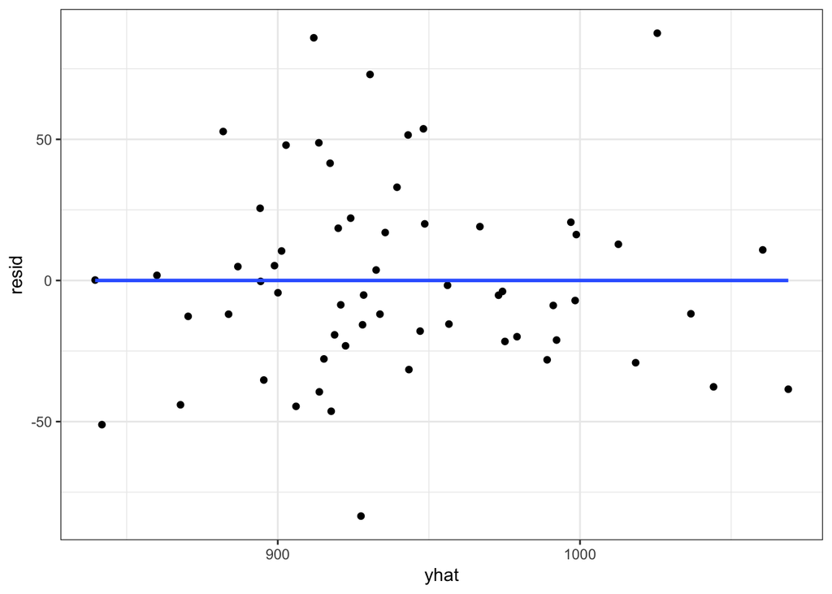

```r
resid <- residuals(best_model)
yhat <- fitted(best_model)

residplot <- ggplot(data=pollution, aes(x=yhat, y=resid))+
  geom_point()+
  geom_smooth(method="lm", se = FALSE)+
  theme_bw()

print(residplot)
```

The residuals look good, the linear fit to the residuals is not sloped in either direction.

## Fitted vs actual mortality

This graph shows the estimated mortality (yhat) calculated from the model coefficients and the observed (known) mortality. The model generally fits the data well except for at the very highest ranges of mortality.

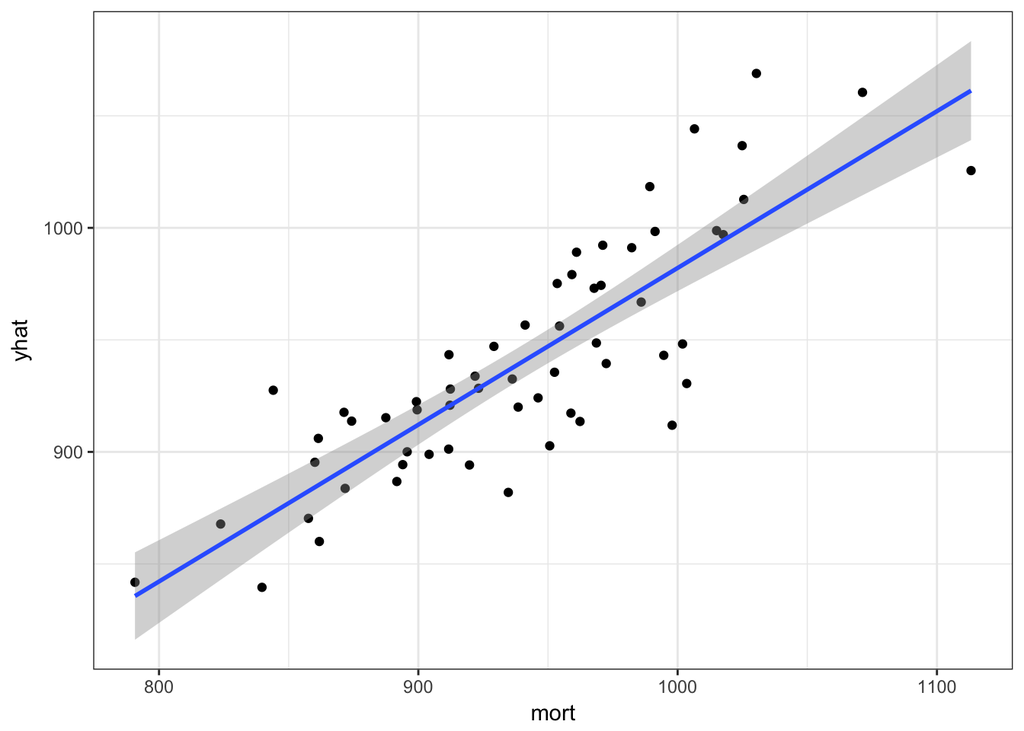

```r
yhatplot <- ggplot(data=pollution, aes(x=mort, y=yhat))+
  geom_point()+
  geom_smooth(method="lm")+
  theme_bw()

print(yhatplot)
```

Summary of the chosen model (mort ~ hc * so2 + jult + educ + nonw)

```r
summary(best_model)
```

```
##
## Call:
## lm(formula = mort ~ hc * so2 + jult + educ + nonw)
##
## Residuals:
##    Min     1Q Median     3Q    Max
## -83.47 -21.24  -4.76  18.65  87.60
##
## Coefficients:
##               Estimate Std. Error t value Pr(>|t|)
## (Intercept)  1.404e+03  1.299e+02  10.811 5.14e-15 ***
## hc          -5.584e-01  2.198e-01  -2.541  0.01402 *
## so2          1.729e-01  1.056e-01   1.637  0.10745
## jult        -4.114e+00  1.467e+00  -2.805  0.00703 **
## educ        -1.973e+01  6.306e+00  -3.128  0.00286 **
## nonw         4.991e+00  7.080e-01   7.050 3.75e-09 ***
## hc:so2       3.259e-03  1.750e-03   1.863  0.06807 .
## ---
## Signif. codes:  0 '***' 0.001 '**' 0.01 '*' 0.05 '.' 0.1 ' ' 1
##
## Residual standard error: 35.97 on 53 degrees of freedom
## Multiple R-squared:  0.6997, Adjusted R-squared:  0.6657
## F-statistic: 20.58 on 6 and 53 DF,  p-value: 2.837e-12
```